# 👖 Branded Resale Bottoms Data Analysis

Welcome to this data exploration project focused on **resale bottoms** — including pants, jeans, shorts, and other branded lower-body apparel.

This project aims to:

- 🧼 Clean and prepare raw product data
- 📊 Analyze brand trends, pricing, and condition distributions
- 📦 Uncover valuable insights for optimizing resale strategy

### 🔧 Tools Used

- Python (pandas, numpy)
- Seaborn & Matplotlib (visualization)
- Jupyter Notebook

## 🧰 1. Imports & Setup

Load all necessary Python libraries and set display/visual settings.

```python
import pandas as pd
import numpy as np
import matplotlib.pyplot as plt
import seaborn as sns
```

```python
#Jupyter inline plotting
%matplotlib inline
#use colorblind to avoid issues
sns.set(style='whitegrid', palette='colorblind')
```

## 📁 2. Load the Dataset

Import the dataset (CSV file), preview the first few rows, and check structure.

```python
df = pd.read_csv('Resale_Bottoms.csv')
```

```python
df.head()
```

|  | designer_names | condition | price | user/seller_score/rating_average | follower_count | location | makeoffer | category | type | created_at | ... | title | category_path | brand | hashtags | created_year | created_month | traits | shipping_options | price_drops | image_path |
| --- | --- | --- | --- | --- | --- | --- | --- | --- | --- | --- | --- | --- | --- | --- | --- | --- | --- | --- | --- | --- | --- |
| 0 | Japanese Brand × Kapital × Mizra Jeans Kyoto | is_used | 160 | 4.755556 | 57 | Asia | True | bottoms | ListProduct | 2025-05-15 13:37:31.298 | ... | Concave Japan Studded Details Tribal Panel Gra... | bottoms.denim | Kapital | [] | 2025 | 5 | {'color': 'gray', 'country_of_origin': 'JP'} | {'us': {'amount': 28}, 'uk': {'amount': 28}, '... | [nan, nan, nan, nan] | kapital/bottoms/listproduct/a5680d5adf694ac889... |
| 1 | Kapital × Number (N)ine × Vintage | is_gently_used | 179 | 5.000000 | 70 | Europe | True | bottoms | ListProduct | 2025-05-14 17:16:20.980 | ... | Vintage Kapital Inspired Hippie Denim Saschiko... | bottoms.denim | Kapital | [] | 2025 | 5 | {'color': 'blue', 'country_of_origin': 'PL'} | {'us': {'amount': 15}, 'uk': {'amount': 15}, '... | [nan, nan, nan, nan] | kapital/bottoms/listproduct/a727e26491ee41659d... |
| 2 | Kapital × Kapital Kountry | is_new | 900 | 4.916667 | 31 | United States | True | bottoms | ListProduct | 2025-05-16 00:48:05.189 | ... | Kapital 14oz Denim 5P Shorts (BONE Embroidery) | bottoms.shorts | Kapital | ['jeans', 'denim', 'skull', 'kapital', 'bone',... | 2025 | 5 | {'color': 'blue', 'country_of_origin': 'JP'} | {'us': {'amount': 13}, 'uk': {'amount': 25}, '... | [nan, nan, nan, nan] | kapital/bottoms/listproduct/650d840e680943da91... |
| 3 | Kapital | is_used | 418 | 4.428571 | 16 | Europe | True | bottoms | ListProduct | 2025-05-15 19:07:50.641 | ... | Steal Grail! Japan Kapital boro jeans pants cu... | bottoms.cropped_pants | Kapital | [] | 2025 | 5 | {'color': 'multi', 'country_of_origin': 'US'} | {'us': {'amount': 20}, 'uk': {'amount': 15}, '... | [nan, nan, nan, nan] | kapital/bottoms/listproduct/6237eedf706d432095... |
| 4 | Kapital | is_new | 601 | 4.948478 | 6 | Asia | True | bottoms | ListProduct | 2025-05-16 20:04:46.704 | ... | Kapital Gemstone Denim Pants Blue Size 32-2505 | bottoms.denim | Kapital | [] | 2025 | 5 | {'color': 'blue', 'country_of_origin': 'JP'} | {'us': {'amount': 0}, 'uk': {'amount': 0}, 'eu... | [nan, nan, nan, nan] | kapital/bottoms/listproduct/f51b3ad8789543bcad... |

5 rows × 24 columns

## 🔍 3. Exploratory Data Analysis (EDA)

### 🧼 3.1 Overview & Cleaning Checks

### 📊 3.2 Descriptive Statistics

```python
df.info()
df.describe()
```

```
<class 'pandas.core.frame.DataFrame'>
RangeIndex: 5440 entries, 0 to 5439
Data columns (total 24 columns):
 #   Column                            Non-Null Count  Dtype
---  ------                            --------------  -----
 0   designer_names                    5440 non-null   object
 1   condition                         5440 non-null   object
 2   price                             5440 non-null   int64
 3   user/seller_score/rating_average  5246 non-null   float64
 4   follower_count                    5440 non-null   int64
 5   location                          5440 non-null   object
 6   makeoffer                         5440 non-null   bool
 7   category                          5440 non-null   object
 8   type                              5440 non-null   object
 9   created_at                        5440 non-null   object
```

[output cut: 16 more lines]

|  | price | user/seller_score/rating_average | follower_count | created_year | created_month |
| --- | --- | --- | --- | --- | --- |
| count | 5440.000000 | 5246.000000 | 5440.000000 | 5440.0 | 5440.000000 |
| mean | 383.786029 | 4.886923 | 15.617831 | 2025.0 | 4.884926 |
| std | 829.662113 | 0.122045 | 38.725035 | 0.0 | 0.320864 |
| min | 9.000000 | 3.454545 | 0.000000 | 2025.0 | 3.000000 |
| 25% | 100.000000 | 4.856971 | 1.000000 | 2025.0 | 5.000000 |
| 50% | 200.000000 | 4.912429 | 4.000000 | 2025.0 | 5.000000 |
| 75% | 475.000000 | 4.961221 | 17.000000 | 2025.0 | 5.000000 |
| max | 29950.000000 | 5.000000 | 996.000000 | 2025.0 | 5.000000 |

```python
df.shape
```

```
(5440, 24)
```

```python
df.isnull().sum()
```

```
designer_names                        0
condition                             0
price                                 0
user/seller_score/rating_average    194
follower_count                        0
location                              0
makeoffer                             0
category                              0
type                                  0
created_at                            0
category_path_size                    0
category_size                         0
color                                35
department                            0
title                                 0
category_path                         0
brand                                 0
hashtags                              0
created_year                          0
created_month                         0
traits                                0
shipping_options                      1
price_drops                           0
image_path                           12
dtype: int64
```

```python
df['brand'].value_counts()
```

```
brand
Levi's           1016
Saint Laurent    1000
Rick Owens       1000
Carhartt          998
Kapital           986
Acne Studios      440
Name: count, dtype: int64
```

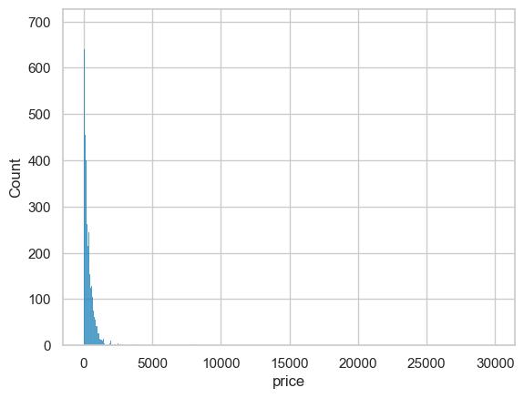

```python
sns.histplot(df['price'])
```

```python
df[['condition', 'location', 'category_path']].apply(pd.Series.value_counts)
```

|  | condition | location | category_path |
| --- | --- | --- | --- |
| Asia | NaN | 2408.0 | NaN |
| Australia/NZ | NaN | 64.0 | NaN |
| Canada | NaN | 167.0 | NaN |
| Europe | NaN | 995.0 | NaN |
| Other | NaN | 42.0 | NaN |
| United Kingdom | NaN | 86.0 | NaN |
| United States | NaN | 1678.0 | NaN |
| bottoms.casual_pants | NaN | NaN | 1143.0 |
| bottoms.cropped_pants | NaN | NaN | 57.0 |
| bottoms.denim | NaN | NaN | 3408.0 |
| bottoms.jumpsuits | NaN | NaN | 39.0 |
| bottoms.leggings | NaN | NaN | 1.0 |
| bottoms.shorts | NaN | NaN | 609.0 |
| bottoms.sweatpants_joggers | NaN | NaN | 176.0 |
| bottoms.swimwear | NaN | NaN | 7.0 |
| is_gently_used | 2407.0 | NaN | NaN |
| is_new | 1073.0 | NaN | NaN |
| is_used | 1822.0 | NaN | NaN |
| is_worn | 138.0 | NaN | NaN |

## 🧹 4. Data Cleaning

```python
df.isnull().sum()
```

```
designer_names                        0
condition                             0
price                                 0
user/seller_score/rating_average    194
follower_count                        0
location                              0
makeoffer                             0
category                              0
type                                  0
created_at                            0
category_path_size                    0
category_size                         0
color                                35
department                            0
title                                 0
category_path                         0
brand                                 0
hashtags                              0
created_year                          0
created_month                         0
traits                                0
shipping_options                      1
price_drops                           0
image_path                           12
dtype: int64
```

```python
df.duplicated().sum()
df = df.drop_duplicates()
```

```python
#clean up names
df.columns = df.columns.str.lower().str.replace(' ', '_').str.replace('/', '_')
```

```python
#Standardize condition category

df['condition'] = df['condition'].str.lower().str.replace('is_', '')
```

```python
df.head()
```

|  | designer_names | condition | price | user_seller_score_rating_average | follower_count | location | makeoffer | category | type | created_at | ... | title | category_path | brand | hashtags | created_year | created_month | traits | shipping_options | price_drops | image_path |
| --- | --- | --- | --- | --- | --- | --- | --- | --- | --- | --- | --- | --- | --- | --- | --- | --- | --- | --- | --- | --- | --- |
| 0 | Japanese Brand × Kapital × Mizra Jeans Kyoto | used | 160 | 4.755556 | 57 | Asia | True | bottoms | ListProduct | 2025-05-15 13:37:31.298 | ... | Concave Japan Studded Details Tribal Panel Gra... | bottoms.denim | Kapital | [] | 2025 | 5 | {'color': 'gray', 'country_of_origin': 'JP'} | {'us': {'amount': 28}, 'uk': {'amount': 28}, '... | [nan, nan, nan, nan] | kapital/bottoms/listproduct/a5680d5adf694ac889... |
| 1 | Kapital × Number (N)ine × Vintage | gently_used | 179 | 5.000000 | 70 | Europe | True | bottoms | ListProduct | 2025-05-14 17:16:20.980 | ... | Vintage Kapital Inspired Hippie Denim Saschiko... | bottoms.denim | Kapital | [] | 2025 | 5 | {'color': 'blue', 'country_of_origin': 'PL'} | {'us': {'amount': 15}, 'uk': {'amount': 15}, '... | [nan, nan, nan, nan] | kapital/bottoms/listproduct/a727e26491ee41659d... |
| 2 | Kapital × Kapital Kountry | new | 900 | 4.916667 | 31 | United States | True | bottoms | ListProduct | 2025-05-16 00:48:05.189 | ... | Kapital 14oz Denim 5P Shorts (BONE Embroidery) | bottoms.shorts | Kapital | ['jeans', 'denim', 'skull', 'kapital', 'bone',... | 2025 | 5 | {'color': 'blue', 'country_of_origin': 'JP'} | {'us': {'amount': 13}, 'uk': {'amount': 25}, '... | [nan, nan, nan, nan] | kapital/bottoms/listproduct/650d840e680943da91... |
| 3 | Kapital | used | 418 | 4.428571 | 16 | Europe | True | bottoms | ListProduct | 2025-05-15 19:07:50.641 | ... | Steal Grail! Japan Kapital boro jeans pants cu... | bottoms.cropped_pants | Kapital | [] | 2025 | 5 | {'color': 'multi', 'country_of_origin': 'US'} | {'us': {'amount': 20}, 'uk': {'amount': 15}, '... | [nan, nan, nan, nan] | kapital/bottoms/listproduct/6237eedf706d432095... |
| 4 | Kapital | new | 601 | 4.948478 | 6 | Asia | True | bottoms | ListProduct | 2025-05-16 20:04:46.704 | ... | Kapital Gemstone Denim Pants Blue Size 32-2505 | bottoms.denim | Kapital | [] | 2025 | 5 | {'color': 'blue', 'country_of_origin': 'JP'} | {'us': {'amount': 0}, 'uk': {'amount': 0}, 'eu... | [nan, nan, nan, nan] | kapital/bottoms/listproduct/f51b3ad8789543bcad... |

5 rows × 24 columns

```python
#clean up hashtags
df['hashtags'] = df['hashtags'].str.lower().str.replace("['", "").str.replace("'", "").str.replace(",", " ")
```

```python
#clean up traits
df['traits'] = df['traits'].str.lower().str.replace("{'", "").str.replace("':", " ").str.replace(
    "'", "").str.replace(",", " ").str.replace('}', '')
```

```python
#clean up shipping
df['shipping_options'] = df['shipping_options'].str.lower().str.replace("{'", "").str.replace("':", " ").str.replace(
    "'", "").str.replace(",", " ").str.replace('}', '')
```

```python
#clean up category path
df['category_path'] = df['category_path'].str.lower().str.replace(".", " ")
```

```python
#clean price drops
df['price_drops'] = df['price_drops'].str.lower().str.replace("[", "").str.replace(",", " ").str.replace(
    ",", " ").str.replace("]", "")
```

```python
df.head()
```

|  | designer_names | condition | price | user_seller_score_rating_average | follower_count | location | makeoffer | category | type | created_at | ... | title | category_path | brand | hashtags | created_year | created_month | traits | shipping_options | price_drops | image_path |
| --- | --- | --- | --- | --- | --- | --- | --- | --- | --- | --- | --- | --- | --- | --- | --- | --- | --- | --- | --- | --- | --- |
| 0 | Japanese Brand × Kapital × Mizra Jeans Kyoto | used | 160 | 4.755556 | 57 | Asia | True | bottoms | ListProduct | 2025-05-15 13:37:31.298 | ... | Concave Japan Studded Details Tribal Panel Gra... | bottoms denim | Kapital | [] | 2025 | 5 | color gray country_of_origin jp | us amount 28 uk amount 28 eu amount 28... | nan nan nan nan | kapital/bottoms/listproduct/a5680d5adf694ac889... |
| 1 | Kapital × Number (N)ine × Vintage | gently_used | 179 | 5.000000 | 70 | Europe | True | bottoms | ListProduct | 2025-05-14 17:16:20.980 | ... | Vintage Kapital Inspired Hippie Denim Saschiko... | bottoms denim | Kapital | [] | 2025 | 5 | color blue country_of_origin pl | us amount 15 uk amount 15 eu amount 15... | nan nan nan nan | kapital/bottoms/listproduct/a727e26491ee41659d... |
| 2 | Kapital × Kapital Kountry | new | 900 | 4.916667 | 31 | United States | True | bottoms | ListProduct | 2025-05-16 00:48:05.189 | ... | Kapital 14oz Denim 5P Shorts (BONE Embroidery) | bottoms shorts | Kapital | jeans denim skull kapital bone shorts ko... | 2025 | 5 | color blue country_of_origin jp | us amount 13 uk amount 25 eu amount 25... | nan nan nan nan | kapital/bottoms/listproduct/650d840e680943da91... |
| 3 | Kapital | used | 418 | 4.428571 | 16 | Europe | True | bottoms | ListProduct | 2025-05-15 19:07:50.641 | ... | Steal Grail! Japan Kapital boro jeans pants cu... | bottoms cropped_pants | Kapital | [] | 2025 | 5 | color multi country_of_origin us | us amount 20 uk amount 15 eu amount 15... | nan nan nan nan | kapital/bottoms/listproduct/6237eedf706d432095... |
| 4 | Kapital | new | 601 | 4.948478 | 6 | Asia | True | bottoms | ListProduct | 2025-05-16 20:04:46.704 | ... | Kapital Gemstone Denim Pants Blue Size 32-2505 | bottoms denim | Kapital | [] | 2025 | 5 | color blue country_of_origin jp | us amount 0 uk amount 0 eu amount 0 c... | nan nan nan nan | kapital/bottoms/listproduct/f51b3ad8789543bcad... |

5 rows × 24 columns

```python
df['created_at'] = pd.to_datetime(df['created_at']).dt.strftime('%m/%d/%y')
```

```python
df['year'] = df['created_at'].dt.year
```

```python
df = df.drop(columns=['category_size'])
```

[output not shown]

```python
df = df.drop(columns=['type'])
```

```python
df.rename(columns={'user_seller_score_rating_average': 'seller_rating'}, inplace=True)
```

```python
df.rename(columns={'category_path_size': 'size'}, inplace=True)
```

```python
df.rename(columns={'created_at': 'listing_date'}, inplace=True)
```

```python
df['size'] = df['size'].str.lower().str.replace('bottoms.denim.', '').str.replace(
    'bottoms.shorts.', '').str.replace('.', '')
```

```python
df.head(3)
```

|  | designer_names | condition | price | seller_rating | follower_count | location | makeoffer | category | listing_date | size | ... | color | department | title | category_path | brand | hashtags | traits | shipping_options | price_drops | image_path |
| --- | --- | --- | --- | --- | --- | --- | --- | --- | --- | --- | --- | --- | --- | --- | --- | --- | --- | --- | --- | --- | --- |
| 0 | Japanese Brand × Kapital × Mizra Jeans Kyoto | used | 160 | 4.755556 | 57 | Asia | True | bottoms | 05/15/25 | 30 | ... | gray | menswear | Concave Japan Studded Details Tribal Panel Gra... | bottoms denim | Kapital | [] | color gray country_of_origin jp | us amount 28 uk amount 28 eu amount 28... | nan nan nan nan | kapital/bottoms/listproduct/a5680d5adf694ac889... |
| 1 | Kapital × Number (N)ine × Vintage | gently_used | 179 | 5.000000 | 70 | Europe | True | bottoms | 05/14/25 | 34 | ... | blue | menswear | Vintage Kapital Inspired Hippie Denim Saschiko... | bottoms denim | Kapital | [] | color blue country_of_origin pl | us amount 15 uk amount 15 eu amount 15... | nan nan nan nan | kapital/bottoms/listproduct/a727e26491ee41659d... |
| 2 | Kapital × Kapital Kountry | new | 900 | 4.916667 | 31 | United States | True | bottoms | 05/16/25 | 32 | ... | blue | menswear | Kapital 14oz Denim 5P Shorts (BONE Embroidery) | bottoms shorts | Kapital | jeans denim skull kapital bone shorts ko... | color blue country_of_origin jp | us amount 13 uk amount 25 eu amount 25... | nan nan nan nan | kapital/bottoms/listproduct/650d840e680943da91... |

3 rows × 21 columns

```python
df.isnull().sum().sort_values(ascending=False)
```

[output not shown]

```python
df = df.to_csv("Resale_Bottoms_Clean.csv", index=False)
```

```python
df = pd.read_csv('Resale_Bottoms_Clean.csv')
```

```python
df.head()
```

|  | designer_names | condition | price | seller_rating | follower_count | location | makeoffer | category | listing_date | size | ... | color | department | title | category_path | brand | hashtags | traits | shipping_options | price_drops | image_path |
| --- | --- | --- | --- | --- | --- | --- | --- | --- | --- | --- | --- | --- | --- | --- | --- | --- | --- | --- | --- | --- | --- |
| 0 | Japanese Brand × Kapital × Mizra Jeans Kyoto | used | 160 | 4.755556 | 57 | Asia | True | bottoms | 05/15/25 | 30 | ... | gray | menswear | Concave Japan Studded Details Tribal Panel Gra... | bottoms denim | Kapital | [] | color gray country_of_origin jp | us amount 28 uk amount 28 eu amount 28... | nan nan nan nan | kapital/bottoms/listproduct/a5680d5adf694ac889... |
| 1 | Kapital × Number (N)ine × Vintage | gently_used | 179 | 5.000000 | 70 | Europe | True | bottoms | 05/14/25 | 34 | ... | blue | menswear | Vintage Kapital Inspired Hippie Denim Saschiko... | bottoms denim | Kapital | [] | color blue country_of_origin pl | us amount 15 uk amount 15 eu amount 15... | nan nan nan nan | kapital/bottoms/listproduct/a727e26491ee41659d... |
| 2 | Kapital × Kapital Kountry | new | 900 | 4.916667 | 31 | United States | True | bottoms | 05/16/25 | 32 | ... | blue | menswear | Kapital 14oz Denim 5P Shorts (BONE Embroidery) | bottoms shorts | Kapital | jeans denim skull kapital bone shorts ko... | color blue country_of_origin jp | us amount 13 uk amount 25 eu amount 25... | nan nan nan nan | kapital/bottoms/listproduct/650d840e680943da91... |
| 3 | Kapital | used | 418 | 4.428571 | 16 | Europe | True | bottoms | 05/15/25 | bottomscropped_pants32 | ... | multi | menswear | Steal Grail! Japan Kapital boro jeans pants cu... | bottoms cropped_pants | Kapital | [] | color multi country_of_origin us | us amount 20 uk amount 15 eu amount 15... | nan nan nan nan | kapital/bottoms/listproduct/6237eedf706d432095... |
| 4 | Kapital | new | 601 | 4.948478 | 6 | Asia | True | bottoms | 05/16/25 | 32 | ... | blue | menswear | Kapital Gemstone Denim Pants Blue Size 32-2505 | bottoms denim | Kapital | [] | color blue country_of_origin jp | us amount 0 uk amount 0 eu amount 0 c... | nan nan nan nan | kapital/bottoms/listproduct/f51b3ad8789543bcad... |

5 rows × 21 columns

```python
df['price_drops'].head()
```

```
0    nan  nan  nan  nan
1    nan  nan  nan  nan
2    nan  nan  nan  nan
3    nan  nan  nan  nan
4    nan  nan  nan  nan
Name: price_drops, dtype: object
```

```python
if 'price_drops' in df.columns:
    df['price_drops'] = df['price_drops'].astype(str)
    df['price_drops'] = df['price_drops'].replace(r'[^\d.]', '', regex=True)
    df['price_drops'] = pd.to_numeric(df['price_drops'], errors='coerce')
```

```python
df['category_size'].head()
```

```
0    bottoms.30
1    bottoms.34
2    bottoms.32
3    bottoms.32
4    bottoms.32
Name: category_size, dtype: object
```

```python
df = df.drop(columns=['category_se'])
```

```python
df.head(2)
```

[output not shown]

### 💡 Decided to Put category size back in and just remove the word 'Bottoms' from it and delete Size column

```python
df = pd.read_csv('Resale_Bottoms_Clean.csv')
```

```python
df = pd.read_csv('Resale_Bottoms_Clean.csv')
print(type(df))
```

```
<class 'pandas.core.frame.DataFrame'>
```

```python
df = df.drop(columns=['size'])
```

```python
df = df.rename(columns={'category_size': 'size'})
```

```python
df['size'] = df['size'].str.lower().str.replace('bottoms.', '')
```

```python
df = df.rename(columns={'category_path': 'type'})
```

```python
df['type'] = df['type'].str.lower().str.replace('bottoms', '')
```

```python
df.head(2)
```

|  | designer_names | condition | price | seller_rating | follower_count | location | makeoffer | category | listing_date | size | color | department | title | type | brand | hashtags | traits | shipping_options | price_drops | image_path |
| --- | --- | --- | --- | --- | --- | --- | --- | --- | --- | --- | --- | --- | --- | --- | --- | --- | --- | --- | --- | --- |
| 0 | Japanese Brand × Kapital × Mizra Jeans Kyoto | used | 160 | 4.755556 | 57 | Asia | True | bottoms | 05/15/25 | 30 | gray | menswear | Concave Japan Studded Details Tribal Panel Gra... | denim | Kapital | [] | color gray country_of_origin jp | us amount 28 uk amount 28 eu amount 28... | nan nan nan nan | kapital/bottoms/listproduct/a5680d5adf694ac889... |
| 1 | Kapital × Number (N)ine × Vintage | gently_used | 179 | 5.000000 | 70 | Europe | True | bottoms | 05/14/25 | 34 | blue | menswear | Vintage Kapital Inspired Hippie Denim Saschiko... | denim | Kapital | [] | color blue country_of_origin pl | us amount 15 uk amount 15 eu amount 15... | nan nan nan nan | kapital/bottoms/listproduct/a727e26491ee41659d... |

```python
df = pd.read_csv('Resale_Bottoms_Clean.csv')
```

```python
df['seller_rating'] = df['seller_rating'].round(2)
```

```python
df.head(2)
```

|  | designer_names | condition | price | seller_rating | follower_count | location | makeoffer | category | listing_date | size | color | department | title | type | brand | hashtags | traits | shipping_options | price_drops | image_path |
| --- | --- | --- | --- | --- | --- | --- | --- | --- | --- | --- | --- | --- | --- | --- | --- | --- | --- | --- | --- | --- |
| 0 | Japanese Brand × Kapital × Mizra Jeans Kyoto | used | 160 | 4.76 | 57 | Asia | True | bottoms | 05/15/25 | 30 | gray | menswear | Concave Japan Studded Details Tribal Panel Gra... | denim | Kapital | [] | color gray country_of_origin jp | us amount 28 uk amount 28 eu amount 28... | nan nan nan nan | kapital/bottoms/listproduct/a5680d5adf694ac889... |
| 1 | Kapital × Number (N)ine × Vintage | gently_used | 179 | 5.00 | 70 | Europe | True | bottoms | 05/14/25 | 34 | blue | menswear | Vintage Kapital Inspired Hippie Denim Saschiko... | denim | Kapital | [] | color blue country_of_origin pl | us amount 15 uk amount 15 eu amount 15... | nan nan nan nan | kapital/bottoms/listproduct/a727e26491ee41659d... |

```python
df.to_csv("Resale_Bottoms_Clean.csv", index=False)
```

```python
df['hashtags'] = df['hashtags'].str.replace(']', '')
```

```python
df['hashtags'] = df['hashtags'].str.replace('[', '')
```

```python
df.head(2)
```

|  | designer_names | condition | price | seller_rating | follower_count | location | makeoffer | category | listing_date | size | color | department | title | type | brand | hashtags | traits | shipping_options | price_drops | image_path |
| --- | --- | --- | --- | --- | --- | --- | --- | --- | --- | --- | --- | --- | --- | --- | --- | --- | --- | --- | --- | --- |
| 0 | Japanese Brand × Kapital × Mizra Jeans Kyoto | used | 160 | 4.76 | 57 | Asia | True | bottoms | 05/15/25 | 30 | gray | menswear | Concave Japan Studded Details Tribal Panel Gra... | denim | Kapital |  | color gray country_of_origin jp | us amount 28 uk amount 28 eu amount 28... | nan nan nan nan | kapital/bottoms/listproduct/a5680d5adf694ac889... |
| 1 | Kapital × Number (N)ine × Vintage | gently_used | 179 | 5.00 | 70 | Europe | True | bottoms | 05/14/25 | 34 | blue | menswear | Vintage Kapital Inspired Hippie Denim Saschiko... | denim | Kapital |  | color blue country_of_origin pl | us amount 15 uk amount 15 eu amount 15... | nan nan nan nan | kapital/bottoms/listproduct/a727e26491ee41659d... |

```python
df.isnull().sum()
```

```
designer_names        0
condition             0
price                 0
seller_rating       194
follower_count        0
location              0
makeoffer             0
category              0
listing_date          0
size                  0
color                35
department            0
title                 0
type                  0
brand                 0
hashtags              0
traits                0
shipping_options      1
price_drops           0
image_path           12
dtype: int64
```

```python
df.fillna({'seller_rating': 'unknown'}, inplace=True)
```

```python
df.fillna({'color': 'unknown'}, inplace=True)
```

```python
df.fillna({'image_path': 'unknown'}, inplace=True)
```

```python
df.fillna({'shipping_options': 'unknown'}, inplace=True)
```

```python
df.isnull().sum()
```

```
designer_names      0
condition           0
price               0
seller_rating       0
follower_count      0
location            0
makeoffer           0
category            0
listing_date        0
size                0
color               0
department          0
title               0
type                0
brand               0
hashtags            0
traits              0
shipping_options    0
price_drops         0
image_path          0
dtype: int64
```

```python
cols_to_numeric = ['price', 'price_drops', 'seller_rating', 'size']
for col in cols_to_numeric:
    df[col] = pd.to_numeric(df[col], errors='coerce')
```

```python
df.info()
```

[output not shown]

```python
df['listing_date'] = pd.to_datetime(df['listing_date'])
```

```python
df.head(3)
```

|  | designer_names | condition | price | seller_rating | follower_count | location | makeoffer | category | listing_date | size | color | department | title | type | brand | hashtags | traits | shipping_options | price_drops | image_path |
| --- | --- | --- | --- | --- | --- | --- | --- | --- | --- | --- | --- | --- | --- | --- | --- | --- | --- | --- | --- | --- |
| 0 | Japanese Brand × Kapital × Mizra Jeans Kyoto | used | 160 | 4.76 | 57 | Asia | True | bottoms | 2025-05-15 | 30 | gray | menswear | Concave Japan Studded Details Tribal Panel Gra... | denim | Kapital |  | color gray country_of_origin jp | us amount 28 uk amount 28 eu amount 28... | NaN | kapital/bottoms/listproduct/a5680d5adf694ac889... |
| 1 | Kapital × Number (N)ine × Vintage | gently_used | 179 | 5.00 | 70 | Europe | True | bottoms | 2025-05-14 | 34 | blue | menswear | Vintage Kapital Inspired Hippie Denim Saschiko... | denim | Kapital |  | color blue country_of_origin pl | us amount 15 uk amount 15 eu amount 15... | NaN | kapital/bottoms/listproduct/a727e26491ee41659d... |
| 2 | Kapital × Kapital Kountry | new | 900 | 4.92 | 31 | United States | True | bottoms | 2025-05-16 | 32 | blue | menswear | Kapital 14oz Denim 5P Shorts (BONE Embroidery) | shorts | Kapital | jeans denim skull kapital bone shorts ko... | color blue country_of_origin jp | us amount 13 uk amount 25 eu amount 25... | NaN | kapital/bottoms/listproduct/650d840e680943da91... |

## 📊 Visualizations and Insights from the Resale Bottoms Dataset

In this section, we explore key trends and patterns using data visualizations.  
These charts provide insights into brand popularity, pricing behavior,  
seller performance, and more within the resale market for branded bottoms.

## 📊 Top Resale Brands - Listing Counts

```python
#top 10 brands
top_brands = df['brand'].value_counts().head(10).reset_index()
top_brands.columns = ['brand', 'count']
```

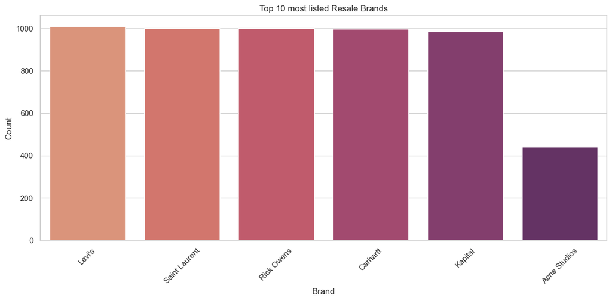

```python
plt.figure(figsize=(12,6))
#bar plot
sns.barplot(data=top_brands, x='brand', y='count', palette='flare')
#label settings
plt.xticks(rotation=45)
plt.title('Top 10 most listed Resale Brands')
plt.xlabel('Brand')
plt.ylabel('Count')
plt.tight_layout()
plt.show()
```

```python
#top 10 designer names
top_designer = df['designer_names'].value_counts().head(10).reset_index()
top_designer.columns = ['designer_names', 'count']
```

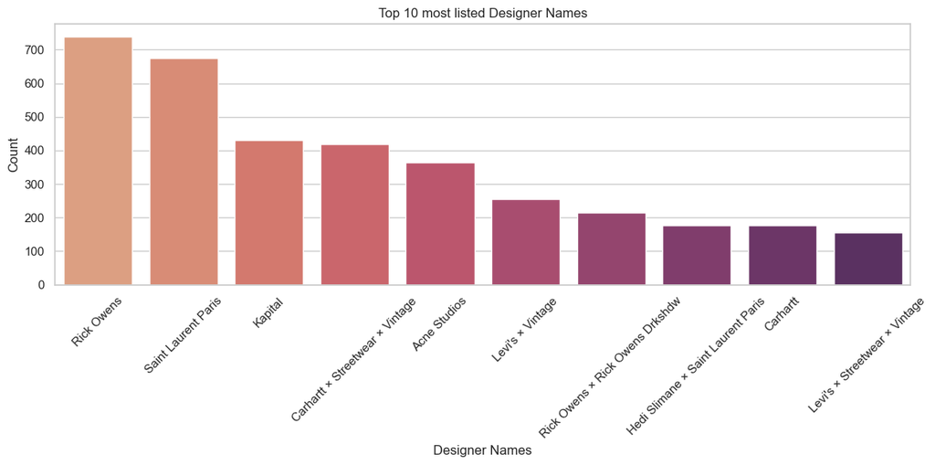

```python
plt.figure(figsize=(12,6))
#bar plot
sns.barplot(data=top_designer, x='designer_names', y='count', palette='flare')
#label settings
plt.xticks(rotation=45)
plt.title('Top 10 most listed Designer Names')
plt.xlabel('Designer Names')
plt.ylabel('Count')
plt.tight_layout()
plt.show()
```

### 💡 Insight

These charts give a quick glance at which brands are listed most frequently.  
All pretty close by Just "brand" name with the exception of Acne Studios falling off  
However when we look at the chart with 'Designer Names' or vintage associated with brand  
Rick Owens and Saint Laurent Paris dominate

## 💵 Distribution of Resale Prices

```python
df['price'] = pd.to_numeric(df['price'], errors='coerce')
```

```python
df_filtered = df[df['price'] < 500]
```

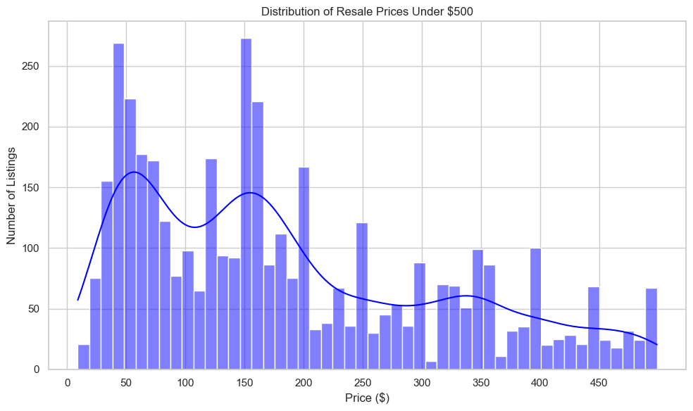

```python
#histogram
plt.figure(figsize=(10,6))

sns.histplot(data=df_filtered, x='price', bins=50, kde=True, color='blue')
plt.xticks(ticks=range(0, 500, 50))
plt.title('Distribution of Resale Prices Under $500')
plt.xlabel('Price ($)')
plt.ylabel('Number of Listings')
plt.tight_layout()
plt.show()
```

```python
df_filtered2 = df[df['price'] >= 500 & (df['price'] <= 2000)]
```

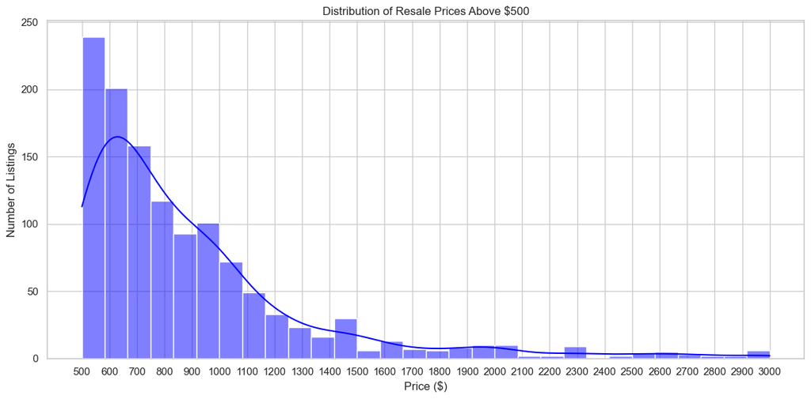

```python
# Filter data between 500 and 3000
df_filtered2 = df[(df['price'] >= 500) & (df['price'] <= 3000)]

# Plot
plt.figure(figsize=(12, 6))
sns.histplot(data=df_filtered2, x='price', bins=30, kde=True, color='blue')
plt.xticks(ticks=range(500, 3001, 100))  # tick marks every $50
plt.title('Distribution of Resale Prices Above $500')
plt.xlabel('Price ($)')
plt.ylabel('Number of Listings')
plt.tight_layout()
plt.show()
```

💡 Insight

First chart is listings under 500, and it shows we primarly have listings around  
50 dollar rand and the 150 range. The second chart is listings above 500 and shows  
$500 is also one of our strong listing price ranges

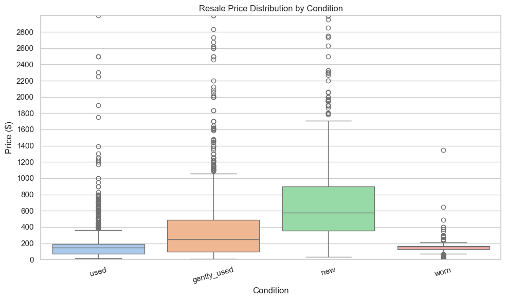

```python
plt.figure(figsize=(10, 6))

sns.boxplot(data=df, x='condition', y='price', palette='pastel')

plt.title('Resale Price Distribution by Condition')
plt.xlabel('Condition')
plt.ylabel('Price ($)')
plt.xticks(rotation=15)
plt.ylim(0, 3000)  # Limit y-axis from 0 to 2500
plt.yticks(ticks=range(0, 3000, 200))
plt.tight_layout()
plt.show()
```

### 💡 Insight

As we can see in the above graph, 'used' and 'worn  
are close in price listing. Possibly showing conditions  
are not accurately taken into account, or condition does not  
play a huge role between the two. As expected 'new' has the  
highest priced listings, with 'gently used' in the middle

```python
size_counts = df['size'].value_counts()
```

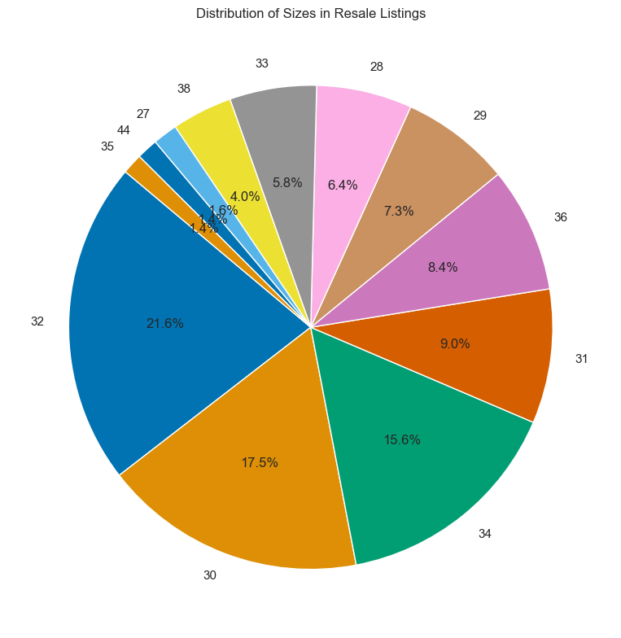

```python
top_sizes = size_counts.nlargest(12)

#plot
plt.figure(figsize=(8, 8))
plt.pie(top_sizes, labels=top_sizes.index, autopct='%1.1f%%', startangle=140, colors=sns.color_palette('colorblind'))
plt.title('Distribution of Sizes in Resale Listings')
plt.tight_layout()
plt.show()
```

### 💡 Insight

From the pie chart we can see Size's {32, 30, 34}  
make up over 50%. Suggesting these are the best sizes to traget

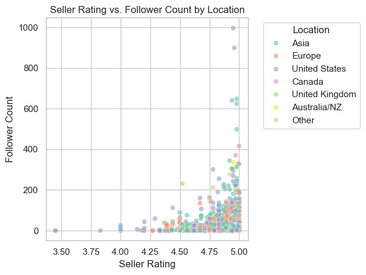

```python
sns.scatterplot(
    data=df,
    x='seller_rating',
    y='follower_count',
    hue='location',
    palette='Set2',
    alpha=0.6
)

plt.title('Seller Rating vs. Follower Count by Location')
plt.xlabel('Seller Rating')
plt.ylabel('Follower Count')
plt.legend(title='Location', bbox_to_anchor=(1.05, 1), loc='upper left')
plt.tight_layout()
plt.show()
```

```python
df.to_csv('Resale_Bottoms_clean.csv', index=False)
```